# 보험 사기 예측

윤지환

2016년 9월 1일

# 보험사기예측

#### 업데이트 사항

- 골절과 관련된 증상 및 사기 연관성이 높은 특정 병명이 있는 것으로 파악
  - M,Q,G 뼈, 선천적 기형, 뇌 및 신경계통
  - 병명 sheet가 정리되어 있는 사이트 http://wpwsyn.tistory.com/152 상병기호와 CLAIM의 RESL_CD1과 동일하게 mapping
- *DATE변수가 영향을 미칠것으로 예상되어 YEAR 요약변수 생성 검증

```r
#Set path
setwd("C:\\workspace_r\\insurance\\")

# CSV Raw Data 불러오기
BGCON_CLAIM_DATA <- read.csv("data/BGCON_CLAIM_DATA.csv")
BGCON_CNTT_DATA <- read.csv("data/BGCON_CNTT_DATA.csv")
BGCON_CUST_DATA <- read.csv("data/BGCON_CUST_DATA.csv") # 기준 데이터
BGCON_FMLY_DATA <- read.csv("data/BGCON_FMLY_DATA.csv")
BGCON_FPINFO_DATA <- read.csv("data/BGCON_FPINFO_DATA.csv")

# 동일한 Level의 필드를 가진 데이터 Bind
BGCON_FMLY_DATA$SIU_CUST_YN <- NULL
BGCON_FPINFO_DATA$SIU_CUST_YN <- NULL
BGCON_CUST_FMLY_DATA <- merge(x = BGCON_CUST_DATA, y = BGCON_FMLY_DATA, by = 'CUST_ID', all = TRUE)
BGCON_CNTT_FPINFO_DATA <- merge(x = BGCON_CNTT_DATA, y = BGCON_FPINFO_DATA, by = 'CLLT_FP_PRNO', all = TRUE)


# SIU_CUST_YN 필드가 비어 있는 데이터(=Test Data)는 제거하고 시작
BGCON_CLAIM_DATA.df <- BGCON_CLAIM_DATA[!(BGCON_CLAIM_DATA$SIU_CUST_YN == ""),]
BGCON_CUST_FMLY_DATA.df <- BGCON_CUST_FMLY_DATA[!(BGCON_CUST_FMLY_DATA$SIU_CUST_YN == ""),]
BGCON_CNTT_FPINFO_DATA.df <- BGCON_CNTT_FPINFO_DATA[!(BGCON_CNTT_FPINFO_DATA$SIU_CUST_YN == ""),]

BGCON_CLAIM_DATA.df$SIU_CUST_YN <- factor(BGCON_CLAIM_DATA.df$SIU_CUST_YN)
BGCON_CLAIM_DATA.df$HOSP_SPEC_DVSN <- factor(BGCON_CLAIM_DATA.df$HOSP_SPEC_DVSN)
BGCON_CLAIM_DATA.df$ACCI_DVSN <- factor(BGCON_CLAIM_DATA.df$ACCI_DVSN)
BGCON_CLAIM_DATA.df$CRNT_PROG_DVSN <- factor(BGCON_CLAIM_DATA.df$CRNT_PROG_DVSN)

BGCON_CUST_FMLY_DATA.df$SIU_CUST_YN <- factor(BGCON_CUST_FMLY_DATA.df$SIU_CUST_YN)
BGCON_CUST_FMLY_DATA.df$RESI_TYPE_CODE <- factor(BGCON_CUST_FMLY_DATA.df$RESI_TYPE_CODE)
BGCON_CUST_FMLY_DATA.df$MINCRDT <- factor(BGCON_CUST_FMLY_DATA.df$MINCRDT)
BGCON_CUST_FMLY_DATA.df$MAXCRDT <- factor(BGCON_CUST_FMLY_DATA.df$MAXCRDT)

BGCON_CNTT_FPINFO_DATA.df$SIU_CUST_YN <- factor(BGCON_CNTT_FPINFO_DATA.df$SIU_CUST_YN)
BGCON_CNTT_FPINFO_DATA.df$CNTT_STAT_CODE <- factor(BGCON_CNTT_FPINFO_DATA.df$CNTT_STAT_CODE)
BGCON_CNTT_FPINFO_DATA.df$PAYM_CYCL_CODE <- factor(BGCON_CNTT_FPINFO_DATA.df$PAYM_CYCL_CODE)
BGCON_CNTT_FPINFO_DATA.df$SALE_CHNL_CODE <- factor(BGCON_CNTT_FPINFO_DATA.df$SALE_CHNL_CODE)
BGCON_CNTT_FPINFO_DATA.df$GOOD_CLSF_CDNM <- factor(BGCON_CNTT_FPINFO_DATA.df$GOOD_CLSF_CDNM)
```

#### 요약 변수 추가

- YEAR 관련 변수 추가

```r
BGCON_CLAIM_DATA.df$RECP_DATE_YEAR <- as.numeric(format(as.Date(as.character(BGCON_CLAIM_DATA.df$RECP_DATE), format = "%Y%m%d"), "%Y"))
BGCON_CLAIM_DATA.df$ORIG_RESN_DATE_YEAR <- as.numeric(format(as.Date(as.character(BGCON_CLAIM_DATA.df$ORIG_RESN_DATE), format = "%Y%m%d"), "%Y"))
BGCON_CLAIM_DATA.df$RESN_DATE_YEAR <- as.numeric(format(as.Date(as.character(BGCON_CLAIM_DATA.df$RESN_DATE), format = "%Y%m%d"), "%Y"))
BGCON_CLAIM_DATA.df$PAYM_DATE_YEAR <- as.numeric(format(as.Date(as.character(BGCON_CLAIM_DATA.df$PAYM_DATE), format = "%Y%m%d"), "%Y"))


BGCON_CUST_FMLY_DATA.df$CUST_RGST_YEAR <- as.numeric(format(as.Date(paste(as.character(BGCON_CUST_FMLY_DATA.df$CUST_RGST), c("01"), sep=""), format = "%Y%m%d"), "%Y"))
BGCON_CUST_FMLY_DATA.df$MAX_PAYM_YM_YEAR <- as.numeric(format(as.Date(paste(as.character(BGCON_CUST_FMLY_DATA.df$MAX_PAYM_YM), c("01"), sep=""), format = "%Y%m%d"), "%Y"))


BGCON_CNTT_FPINFO_DATA.df$CNTT_YM_YEAR <- as.numeric(format(as.Date(paste(as.character(BGCON_CNTT_FPINFO_DATA.df$CNTT_YM), c("01"), sep=""), format = "%Y%m%d"), "%Y"))
BGCON_CNTT_FPINFO_DATA.df$EXPR_YM_YEAR <- as.numeric(format(as.Date(paste(as.character(BGCON_CNTT_FPINFO_DATA.df$EXPR_YM), c("01"), sep=""), format = "%Y%m%d"), "%Y"))
BGCON_CNTT_FPINFO_DATA.df$EXTN_YM_YEAR <- as.numeric(format(as.Date(paste(as.character(BGCON_CNTT_FPINFO_DATA.df$EXTN_YM), c("01"), sep=""), format = "%Y%m%d"), "%Y"))
BGCON_CNTT_FPINFO_DATA.df$LAPS_YM_YEAR <- as.numeric(format(as.Date(paste(as.character(BGCON_CNTT_FPINFO_DATA.df$LAPS_YM), c("01"), sep=""), format = "%Y%m%d"), "%Y"))
BGCON_CNTT_FPINFO_DATA.df$ETRS_YM_YEAR <- as.numeric(format(as.Date(paste(as.character(BGCON_CNTT_FPINFO_DATA.df$ETRS_YM), c("01"), sep=""), format = "%Y%m%d"), "%Y"))
BGCON_CNTT_FPINFO_DATA.df$FIRE_YM_YEAR <- as.numeric(format(as.Date(paste(as.character(BGCON_CNTT_FPINFO_DATA.df$FIRE_YM), c("01"), sep=""), format = "%Y%m%d"), "%Y"))
```

- 각 YEAR 변수의 중앙 YEAR를 만들어줌

```r
median(BGCON_CLAIM_DATA.df[which(BGCON_CLAIM_DATA.df$CUST_ID == 8170), "PAYM_DATE_YEAR"])
```

```
## [1] 2010
```

```r
median(BGCON_CLAIM_DATA.df[which(BGCON_CLAIM_DATA.df$CUST_ID == 3878) && !is.na(BGCON_CLAIM_DATA.df$RECP_DATE_YEAR), "RECP_DATE_YEAR"])
```

```
## [1] 2012
```

```r
median(BGCON_CLAIM_DATA.df[!is.na(BGCON_CLAIM_DATA.df$ORIG_RESN_DATE_YEAR), "ORIG_RESN_DATE_YEAR"])
```

```
## [1] 2011
```

```r
median(BGCON_CLAIM_DATA.df[!is.na(BGCON_CLAIM_DATA.df$RESN_DATE_YEAR), "RESN_DATE_YEAR"])
```

```
## [1] 2012
```

```r
median(BGCON_CLAIM_DATA.df[!is.na(BGCON_CLAIM_DATA.df$PAYM_DATE_YEAR), "PAYM_DATE_YEAR"])
```

```
## [1] 2012
```

```r
median(BGCON_CUST_FMLY_DATA.df[!is.na(BGCON_CUST_FMLY_DATA.df$CUST_RGST_YEAR), "CUST_RGST_YEAR"])
```

```
## [1] 2003
```

```r
median(BGCON_CUST_FMLY_DATA.df[!is.na(BGCON_CUST_FMLY_DATA.df$MAX_PAYM_YM_YEAR), "MAX_PAYM_YM_YEAR"])
```

```
## [1] 2009
```

```r
median(BGCON_CNTT_FPINFO_DATA.df[!is.na(BGCON_CNTT_FPINFO_DATA.df$CNTT_YM_YEAR), "CNTT_YM_YEAR"])
```

```
## [1] 2006
```

```r
median(BGCON_CNTT_FPINFO_DATA.df[!is.na(BGCON_CNTT_FPINFO_DATA.df$EXPR_YM_YEAR), "EXPR_YM_YEAR"])
```

```
## [1] 9999
```

```r
median(BGCON_CNTT_FPINFO_DATA.df[!is.na(BGCON_CNTT_FPINFO_DATA.df$EXTN_YM_YEAR), "EXTN_YM_YEAR"])
```

```
## [1] 2009
```

```r
median(BGCON_CNTT_FPINFO_DATA.df[!is.na(BGCON_CNTT_FPINFO_DATA.df$LAPS_YM_YEAR), "LAPS_YM_YEAR"])
```

```
## [1] 2009
```

```r
median(BGCON_CNTT_FPINFO_DATA.df[!is.na(BGCON_CNTT_FPINFO_DATA.df$ETRS_YM_YEAR), "ETRS_YM_YEAR"])
```

```
## [1] 2001
```

```r
median(BGCON_CNTT_FPINFO_DATA.df[!is.na(BGCON_CNTT_FPINFO_DATA.df$FIRE_YM_YEAR), "FIRE_YM_YEAR"])
```

```
## [1] 2011
```

- 병명의 앞 글자만 추출하여 변수 추가

```r
BGCON_CLAIM_DATA.df$CAUS_CODE_FIRST <- substring(BGCON_CLAIM_DATA.df$CAUS_CODE, 1, 1)
BGCON_CLAIM_DATA.df$RESL_CD1_FIRST <- substring(BGCON_CLAIM_DATA.df$RESL_CD1, 1, 1)
```

- Numeric 관련 요약변수 생성

```r
#다른 필드의 값을 Sum 하여 df1 필드에 채워줌
merge_after_aggregate <- function(df1, df2, by, t_col, c_col){
  agg_df_temp <- aggregate(df2[, t_col], by=list(df2[, by]), FUN=sum)
  colnames(agg_df_temp) <- c(by, c_col)
  ret_df <- merge(x = df1, y = agg_df_temp, by = by, all=TRUE)
  return (ret_df)
}

BGCON_CUST_FMLY_DATA.df <- merge_after_aggregate(BGCON_CUST_FMLY_DATA.df, BGCON_CLAIM_DATA.df, "CUST_ID", "VLID_HOSP_OTDA", "VLID_HOSP_OTDA_TOTAL")
BGCON_CUST_FMLY_DATA.df <- merge_after_aggregate(BGCON_CUST_FMLY_DATA.df, BGCON_CLAIM_DATA.df, "CUST_ID", "HOUSE_HOSP_DIST", "HOUSE_HOSP_DIST_TOTAL")
BGCON_CUST_FMLY_DATA.df <- merge_after_aggregate(BGCON_CUST_FMLY_DATA.df, BGCON_CLAIM_DATA.df, "CUST_ID", "DMND_AMT", "DMND_AMT_TOTAL")
BGCON_CUST_FMLY_DATA.df <- merge_after_aggregate(BGCON_CUST_FMLY_DATA.df, BGCON_CLAIM_DATA.df, "CUST_ID", "PAYM_AMT", "PAYM_AMT_TOTAL")
BGCON_CUST_FMLY_DATA.df <- merge_after_aggregate(BGCON_CUST_FMLY_DATA.df, BGCON_CLAIM_DATA.df, "CUST_ID", "SELF_CHAM", "SELF_CHAM_TOTAL")
BGCON_CUST_FMLY_DATA.df <- merge_after_aggregate(BGCON_CUST_FMLY_DATA.df, BGCON_CLAIM_DATA.df, "CUST_ID", "NON_PAY", "NON_PAY_TOTAL")
BGCON_CUST_FMLY_DATA.df <- merge_after_aggregate(BGCON_CUST_FMLY_DATA.df, BGCON_CLAIM_DATA.df, "CUST_ID", "TAMT_SFCA", "TAMT_SFCA_TOTAL")
BGCON_CUST_FMLY_DATA.df <- merge_after_aggregate(BGCON_CUST_FMLY_DATA.df, BGCON_CLAIM_DATA.df, "CUST_ID", "PATT_CHRG_TOTA", "PATT_CHRG_TOTA_TOTAL")
BGCON_CUST_FMLY_DATA.df <- merge_after_aggregate(BGCON_CUST_FMLY_DATA.df, BGCON_CLAIM_DATA.df, "CUST_ID", "DSCT_AMT", "DSCT_AMT_TOTAL")
BGCON_CUST_FMLY_DATA.df <- merge_after_aggregate(BGCON_CUST_FMLY_DATA.df, BGCON_CLAIM_DATA.df, "CUST_ID", "COUNT_TRMT_ITEM", "COUNT_TRMT_ITEM_TOTAL")


BGCON_CUST_FMLY_DATA.df <- merge_after_aggregate(BGCON_CUST_FMLY_DATA.df, BGCON_CNTT_FPINFO_DATA.df, "CUST_ID", "REAL_PAYM_TERM", "REAL_PAYM_TERM_TOTAL")
BGCON_CUST_FMLY_DATA.df <- merge_after_aggregate(BGCON_CUST_FMLY_DATA.df, BGCON_CNTT_FPINFO_DATA.df, "CUST_ID", "MAIN_INSR_AMT", "MAIN_INSR_AMT_TOTAL")
```

[output not shown]

[output cut: 24 more lines]

[output not shown]

```r
BGCON_CUST_FMLY_DATA.df <- merge_after_aggregate(BGCON_CUST_FMLY_DATA.df, BGCON_CNTT_FPINFO_DATA.df, "CUST_ID", "SUM_ORIG_PREM", "SUM_ORIG_PREM_TOTAL")
BGCON_CUST_FMLY_DATA.df <- merge_after_aggregate(BGCON_CUST_FMLY_DATA.df, BGCON_CNTT_FPINFO_DATA.df, "CUST_ID", "MNTH_INCM_AMT", "MNTH_INCM_AMT_TOTAL")
BGCON_CUST_FMLY_DATA.df <- merge_after_aggregate(BGCON_CUST_FMLY_DATA.df, BGCON_CNTT_FPINFO_DATA.df, "CUST_ID", "DISTANCE", "DISTANCE_TOTAL")
```

```r
# 데이터 셋 random reduced
suppressPackageStartupMessages({
  library(caret)
})
set.seed(1234)
BGCON_CLAIM_DATA.df.down <- downSample(x = BGCON_CLAIM_DATA.df, y = BGCON_CLAIM_DATA.df$SIU_CUST_YN)
set.seed(1234)
BGCON_CUST_FMLY_DATA.df.down <- downSample(x = BGCON_CUST_FMLY_DATA.df, y =  BGCON_CUST_FMLY_DATA.df$SIU_CUST_YN)
set.seed(1234)
BGCON_CNTT_FPINFO_DATA.df.down <- downSample(x = BGCON_CNTT_FPINFO_DATA.df, y = BGCON_CNTT_FPINFO_DATA.df$SIU_CUST_YN)


# 불필요한 Raw Data 삭제
rm(BGCON_CUST_DATA)
rm(BGCON_FMLY_DATA)
rm(BGCON_CNTT_DATA)
rm(BGCON_FPINFO_DATA)
```

## EDA 수행

```r
#install.packages("Amelia")
suppressPackageStartupMessages({
  require(Amelia)
})
```

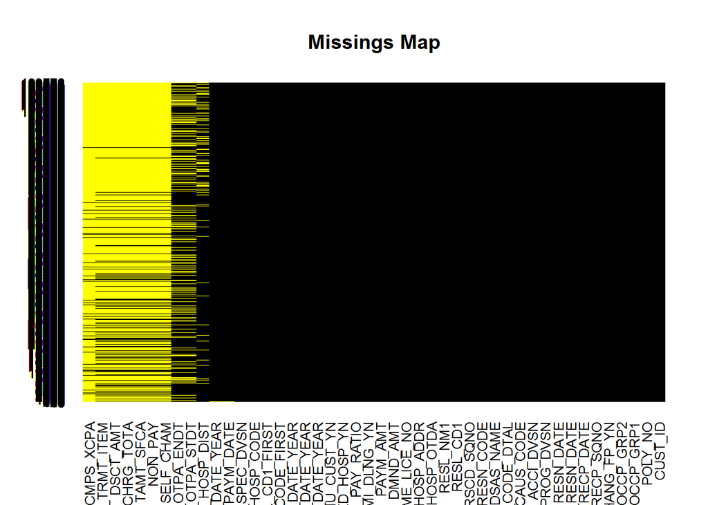

```r
missmap(BGCON_CLAIM_DATA.df, main="Missings Map", col=c("yellow", "black"), legend=FALSE)
```

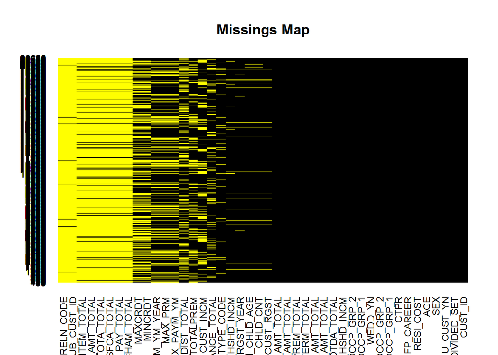

```r
missmap(BGCON_CUST_FMLY_DATA.df, main="Missings Map", col=c("yellow", "black"), legend=FALSE)
```

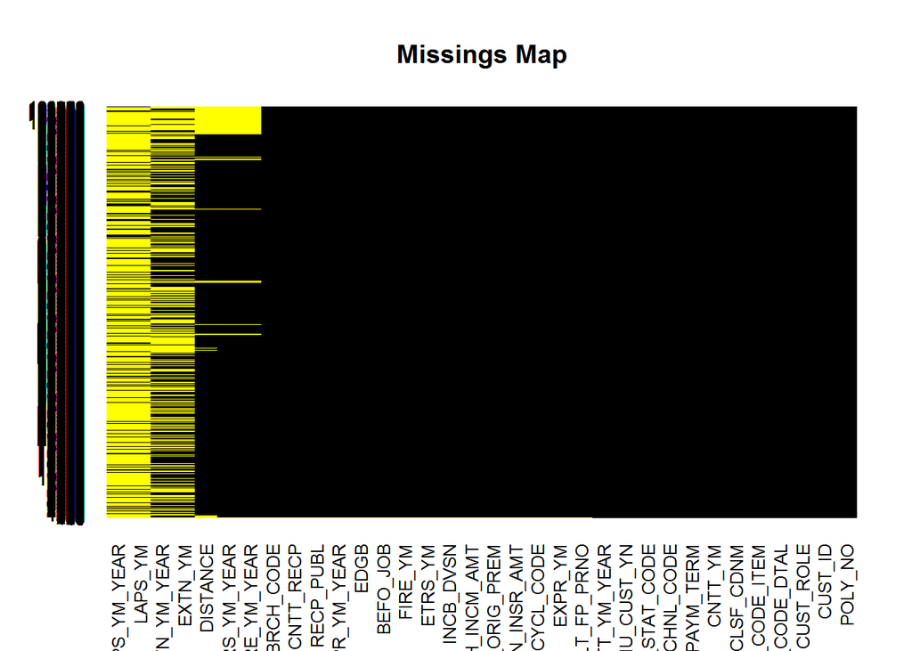

```r
missmap(BGCON_CNTT_FPINFO_DATA.df, main="Missings Map", col=c("yellow", "black"), legend=FALSE)
```

- 실효년월(LAPS_YM) 이 대부분 비어 있음
- 소멸년월(EXTN_YM) 많이 비어 있음
- FP와 고객간의거리(DISTANCE)는 일부 비어 있음
- MAXCRDT, MINCRDT는 중요한 factor로 보이지만 많은 데이터가 비어 있음

```r
#install.packages("Hmisc")
suppressPackageStartupMessages({
  library(Hmisc)
})
names(BGCON_CLAIM_DATA.df)
```

```
##  [1] "CUST_ID"             "POLY_NO"             "ACCI_OCCP_GRP1"
##  [4] "ACCI_OCCP_GRP2"      "CHANG_FP_YN"         "CNTT_RECP_SQNO"
##  [7] "RECP_DATE"           "ORIG_RESN_DATE"      "RESN_DATE"
## [10] "CRNT_PROG_DVSN"      "ACCI_DVSN"           "CAUS_CODE"
## [13] "CAUS_CODE_DTAL"      "DSAS_NAME"           "DMND_RESN_CODE"
## [16] "DMND_RSCD_SQNO"      "HOSP_OTPA_STDT"      "HOSP_OTPA_ENDT"
## [19] "RESL_CD1"            "RESL_NM1"            "VLID_HOSP_OTDA"
## [22] "HOUSE_HOSP_DIST"     "HOSP_CODE"           "ACCI_HOSP_ADDR"
## [25] "HOSP_SPEC_DVSN"      "CHME_LICE_NO"        "PAYM_DATE"
## [28] "DMND_AMT"            "PAYM_AMT"            "PMMI_DLNG_YN"
## [31] "SELF_CHAM"           "NON_PAY"             "TAMT_SFCA"
## [34] "PATT_CHRG_TOTA"      "DSCT_AMT"            "COUNT_TRMT_ITEM"
## [37] "DCAF_CMPS_XCPA"      "NON_PAY_RATIO"       "HEED_HOSP_YN"
## [40] "SIU_CUST_YN"         "RECP_DATE_YEAR"      "ORIG_RESN_DATE_YEAR"
## [43] "RESN_DATE_YEAR"      "PAYM_DATE_YEAR"      "CAUS_CODE_FIRST"
## [46] "RESL_CD1_FIRST"
```

```r
summary(SIU_CUST_YN ~ ACCI_OCCP_GRP1 + ACCI_OCCP_GRP2 + CHANG_FP_YN + CRNT_PROG_DVSN + ACCI_DVSN + DMND_RESN_CODE + DMND_RSCD_SQNO + VLID_HOSP_OTDA + HOUSE_HOSP_DIST + ACCI_HOSP_ADDR + HOSP_SPEC_DVSN + DMND_AMT + PAYM_AMT + PMMI_DLNG_YN + SELF_CHAM + NON_PAY + TAMT_SFCA + PATT_CHRG_TOTA + DSCT_AMT + COUNT_TRMT_ITEM + DCAF_CMPS_XCPA + NON_PAY_RATIO + HEED_HOSP_YN, data = BGCON_CLAIM_DATA.df, method="reverse")
```

```
##
##
## Descriptive Statistics by SIU_CUST_YN
##
## +-------------------+------+-----------------------------+-----------------------------+
## |                   |N     |N                            |Y                            |
## |                   |      |(N=85209)                    |(N=24564)                    |
## +-------------------+------+-----------------------------+-----------------------------+
## |ACCI_OCCP_GRP1 :   |109773|          1% ( 1263)         |          0% (   56)         |
## +-------------------+------+-----------------------------+-----------------------------+
## |    1.주부         |      |         20% (16922)         |         26% ( 6284)         |
## +-------------------+------+-----------------------------+-----------------------------+
## |    2.자영업       |      |         10% ( 8323)         |         16% ( 3922)         |
## +-------------------+------+-----------------------------+-----------------------------+
## |    3.사무직       |      |         11% ( 9735)         |         11% ( 2622)         |
## +-------------------+------+-----------------------------+-----------------------------+
## |    4.전문직       |      |          7% ( 5962)         |          4% ( 1004)         |
## +-------------------+------+-----------------------------+-----------------------------+
## |    5.서비스       |      |         17% (14420)         |         20% ( 4807)         |
## +-------------------+------+-----------------------------+-----------------------------+
## |    6.제조업       |      |          7% ( 5596)         |          4% (  985)         |
## +-------------------+------+-----------------------------+-----------------------------+
## |    7.1차산업      |      |          2% ( 1563)         |          1% (  246)         |
## +-------------------+------+-----------------------------+-----------------------------+
## |    8.기타         |      |         25% (21425)         |         19% ( 4638)         |
## +-------------------+------+-----------------------------+-----------------------------+
## |ACCI_OCCP_GRP2 :   |109773|          1% ( 1263)         |          0% (   56)         |
## +-------------------+------+-----------------------------+-----------------------------+
## |    1차산업 종사자 |      |          2% ( 1777)         |          1% (  294)         |
## +-------------------+------+-----------------------------+-----------------------------+
## |    2차산업 종사자 |      |         10% ( 8711)         |          7% ( 1661)         |
## +-------------------+------+-----------------------------+-----------------------------+
## |    3차산업 종사자 |      |         13% (11487)         |         18% ( 4359)         |
## +-------------------+------+-----------------------------+-----------------------------+
## |    고소득 전문직  |      |          0% (   25)         |          0% (    0)         |
## +-------------------+------+-----------------------------+-----------------------------+
## |    고소득의료직   |      |          0% (  372)         |          0% (   30)         |
## +-------------------+------+-----------------------------+-----------------------------+
## |    고위 공무원    |      |          0% (  338)         |          0% (   33)         |
## +-------------------+------+-----------------------------+-----------------------------+
```

[output cut: 155 more lines]

```
## +-------------------+------+-----------------------------+-----------------------------+
## |    1              |      |         95% (15882)         |         96% (  896)         |
## +-------------------+------+-----------------------------+-----------------------------+
## |    2              |      |          4% (  682)         |          3% (   29)         |
## +-------------------+------+-----------------------------+-----------------------------+
## |    3              |      |          0% (   66)         |          1% (    6)         |
## +-------------------+------+-----------------------------+-----------------------------+
## |    4              |      |          0% (   10)         |          0% (    0)         |
## +-------------------+------+-----------------------------+-----------------------------+
## |DCAF_CMPS_XCPA     |  7471|   10000.0/ 25000.0/ 95000.0 |    9925.0/ 40000.0/207276.2 |
## +-------------------+------+-----------------------------+-----------------------------+
## |NON_PAY_RATIO      |109773|            0/0/0            |            0/0/0            |
## +-------------------+------+-----------------------------+-----------------------------+
## |HEED_HOSP_YN : Y   |109773|          2% ( 2114)         |          4% (  893)         |
## +-------------------+------+-----------------------------+-----------------------------+
```

```r
summary(SIU_CUST_YN ~ ., data = BGCON_CUST_FMLY_DATA.df, method="reverse")
```

```
##
##
## Descriptive Statistics by SIU_CUST_YN
##
## +---------------------+-----+--------------------------------+--------------------------------+
## |                     |N    |N                               |Y                               |
## |                     |     |(N=18804)                       |(N=1851)                        |
## +---------------------+-----+--------------------------------+--------------------------------+
## |CUST_ID              |20655|    5619.50/11174.50/16798.25   |    5559.50/11637.00/16740.00   |
## +---------------------+-----+--------------------------------+--------------------------------+
## |DIVIDED_SET          |20655|            0% (    0)          |            0% (    0)          |
## +---------------------+-----+--------------------------------+--------------------------------+
## |SEX : 2              |20655|           56% (10492)          |           63% ( 1174)          |
## +---------------------+-----+--------------------------------+--------------------------------+
## |AGE                  |20655|            34/46/56            |            38/49/57            |
## +---------------------+-----+--------------------------------+--------------------------------+
## |RESI_COST            |20655|         6805/12340/21388       |         6106/10564/17153       |
## +---------------------+-----+--------------------------------+--------------------------------+
## |RESI_TYPE_CODE : 11  |19503|            9% (1523)           |            7% ( 133)           |
## +---------------------+-----+--------------------------------+--------------------------------+
## |    12               |     |           12% (2088)           |           14% ( 248)           |
## +---------------------+-----+--------------------------------+--------------------------------+
## |    13               |     |            4% ( 677)           |            5% (  84)           |
## +---------------------+-----+--------------------------------+--------------------------------+
## |    20               |     |           51% (9038)           |           44% ( 784)           |
## +---------------------+-----+--------------------------------+--------------------------------+
## |    30               |     |           11% (1953)           |           14% ( 242)           |
## +---------------------+-----+--------------------------------+--------------------------------+
## |    40               |     |            7% (1188)           |            9% ( 165)           |
## +---------------------+-----+--------------------------------+--------------------------------+
## |    50               |     |            0% (  51)           |            1% (   9)           |
## +---------------------+-----+--------------------------------+--------------------------------+
## |    60               |     |            0% (  43)           |            0% (   3)           |
## +---------------------+-----+--------------------------------+--------------------------------+
## |    70               |     |            0% (  28)           |            0% (   1)           |
## +---------------------+-----+--------------------------------+--------------------------------+
## |    99               |     |            6% (1127)           |            7% ( 118)           |
## +---------------------+-----+--------------------------------+--------------------------------+
## |FP_CAREER : Y        |20655|            5% (  943)          |           10% (  176)          |
## +---------------------+-----+--------------------------------+--------------------------------+
```

[output cut: 299 more lines]

```
## +---------------------+-----+--------------------------------+--------------------------------+
## |DSCT_AMT_TOTAL       | 2227|        0.00/ 27.50/238.25      |        0.00/  2.00/865.50      |
## +---------------------+-----+--------------------------------+--------------------------------+
## |COUNT_TRMT_ITEM_TOTAL| 2227|              1/2/4             |              2/4/9             |
## +---------------------+-----+--------------------------------+--------------------------------+
## |REAL_PAYM_TERM_TOTAL |20655|         20.0/40.0/82.0         |         25.0/50.0/99.5         |
## +---------------------+-----+--------------------------------+--------------------------------+
## |MAIN_INSR_AMT_TOTAL  |20557|   3.50e+07/8.00e+07/1.70e+08   |   4.16e+07/9.70e+07/2.12e+08   |
## +---------------------+-----+--------------------------------+--------------------------------+
## |SUM_ORIG_PREM_TOTAL  |20597|   128741.2/ 327093.5/1084825.5 |   131665.0/ 367260.0/1253349.0 |
## +---------------------+-----+--------------------------------+--------------------------------+
## |MNTH_INCM_AMT_TOTAL  |20597|    2000000/ 5400000/12500000   |    2400000/ 6000000/14000000   |
## +---------------------+-----+--------------------------------+--------------------------------+
## |DISTANCE_TOTAL       |17299|            10/ 36/146          |            12/ 48/226          |
## +---------------------+-----+--------------------------------+--------------------------------+
```

- FP경력(FP_CAREER)이 5% 더 높음 하지만, 모수가 많지 않음
- 신용등급_최소(MINCRDT)의 경우 7등급 이하의 하위가 더 높음
- 신용등급_최대(MAXCRDT)의 경우 7등급 이하의 하위가 더 높음
- 결혼여부(WEDD_YN) 결혼한 경우가 4% 더 높음
- FMLY_RELN_CODE 형제 자매의 관계에서 사기로 분류된 경우가 많음, 가족 아이디로 엮인 부분이 더 많음

```r
summary(SIU_CUST_YN ~ CUST_ROLE + IRKD_CODE_DTAL + IRKD_CODE_ITEM + GOOD_CLSF_CDNM + REAL_PAYM_TERM + SALE_CHNL_CODE + CNTT_STAT_CODE + PAYM_CYCL_CODE + MAIN_INSR_AMT + SUM_ORIG_PREM + RECP_PUBL + CNTT_RECP + MNTH_INCM_AMT + DISTANCE + INCB_DVSN + BEFO_JOB + EDGB + BRCH_CODE, data = BGCON_CNTT_FPINFO_DATA.df, method="reverse")
```

```
##
##
## Descriptive Statistics by SIU_CUST_YN
##
## +---------------------+------+--------------------+--------------------+
## |                     |N     |N                   |Y                   |
## |                     |      |(N=93773)           |(N=10241)           |
## +---------------------+------+--------------------+--------------------+
## |CUST_ROLE : 0        |104014|     21% (19295)    |     25% ( 2563)    |
## +---------------------+------+--------------------+--------------------+
## |    1                |      |     42% (39607)    |     45% ( 4657)    |
## +---------------------+------+--------------------+--------------------+
## |    2                |      |     25% (23452)    |     20% ( 2082)    |
## +---------------------+------+--------------------+--------------------+
## |    3                |      |      1% (  475)    |      1% (   86)    |
## +---------------------+------+--------------------+--------------------+
## |    4                |      |      0% (  324)    |      1% (   82)    |
## +---------------------+------+--------------------+--------------------+
## |    5                |      |      8% ( 7841)    |      6% (  628)    |
## +---------------------+------+--------------------+--------------------+
## |    21               |      |      3% ( 2779)    |      1% (  143)    |
## +---------------------+------+--------------------+--------------------+
## |IRKD_CODE_DTAL       |104014|   1257/1604/1627   |   1257/1560/1626   |
## +---------------------+------+--------------------+--------------------+
## |IRKD_CODE_ITEM       |104014|       4/13/39      |       3/11/27      |
## +---------------------+------+--------------------+--------------------+
## |GOOD_CLSF_CDNM : 교육|104014|      0% (  454)    |      1% (   61)    |
## +---------------------+------+--------------------+--------------------+
## |    변액CI           |      |      9% ( 8495)    |      8% (  855)    |
## +---------------------+------+--------------------+--------------------+
## |    변액연금         |      |      6% ( 5462)    |      5% (  507)    |
## +---------------------+------+--------------------+--------------------+
## |    변액저축         |      |      1% ( 1287)    |      1% (  142)    |
## +---------------------+------+--------------------+--------------------+
## |    변액종신         |      |      5% ( 4221)    |      4% (  434)    |
## +---------------------+------+--------------------+--------------------+
## |    보장             |      |     28% (25830)    |     29% ( 2975)    |
## +---------------------+------+--------------------+--------------------+
## |    실손             |      |      1% (  578)    |      0% (   32)    |
## +---------------------+------+--------------------+--------------------+
```

[output cut: 151 more lines]

```
## +---------------------+------+--------------------+--------------------+
## |    고졸             |      |     51% (48086)    |     60% ( 6132)    |
## +---------------------+------+--------------------+--------------------+
## |    대학원졸         |      |      0% (  240)    |      0% (   13)    |
## +---------------------+------+--------------------+--------------------+
## |    대학졸           |      |      7% ( 6320)    |      5% (  515)    |
## +---------------------+------+--------------------+--------------------+
## |    전문대졸         |      |      4% ( 3925)    |      2% (  243)    |
## +---------------------+------+--------------------+--------------------+
## |    중졸             |      |      1% ( 1219)    |      1% (   89)    |
## +---------------------+------+--------------------+--------------------+
## |    초등졸           |      |      0% (  235)    |      0% (   22)    |
## +---------------------+------+--------------------+--------------------+
## |BRCH_CODE            |103940|      49/107/160    |      51/106/160    |
## +---------------------+------+--------------------+--------------------+
```

## 상관분석

```r
# 상관분석
#install.packages("corrgram")
#install.packages("plyr")
suppressPackageStartupMessages({
  require(corrgram)
  require(plyr)
})
#####BGCON_CLAIM_DATA.df
corrgram.data <- BGCON_CLAIM_DATA.df.down
names(corrgram.data)
```

```
##  [1] "CUST_ID"             "POLY_NO"             "ACCI_OCCP_GRP1"
##  [4] "ACCI_OCCP_GRP2"      "CHANG_FP_YN"         "CNTT_RECP_SQNO"
##  [7] "RECP_DATE"           "ORIG_RESN_DATE"      "RESN_DATE"
## [10] "CRNT_PROG_DVSN"      "ACCI_DVSN"           "CAUS_CODE"
## [13] "CAUS_CODE_DTAL"      "DSAS_NAME"           "DMND_RESN_CODE"
## [16] "DMND_RSCD_SQNO"      "HOSP_OTPA_STDT"      "HOSP_OTPA_ENDT"
## [19] "RESL_CD1"            "RESL_NM1"            "VLID_HOSP_OTDA"
## [22] "HOUSE_HOSP_DIST"     "HOSP_CODE"           "ACCI_HOSP_ADDR"
## [25] "HOSP_SPEC_DVSN"      "CHME_LICE_NO"        "PAYM_DATE"
## [28] "DMND_AMT"            "PAYM_AMT"            "PMMI_DLNG_YN"
## [31] "SELF_CHAM"           "NON_PAY"             "TAMT_SFCA"
## [34] "PATT_CHRG_TOTA"      "DSCT_AMT"            "COUNT_TRMT_ITEM"
## [37] "DCAF_CMPS_XCPA"      "NON_PAY_RATIO"       "HEED_HOSP_YN"
## [40] "SIU_CUST_YN"         "RECP_DATE_YEAR"      "ORIG_RESN_DATE_YEAR"
## [43] "RESN_DATE_YEAR"      "PAYM_DATE_YEAR"      "CAUS_CODE_FIRST"
## [46] "RESL_CD1_FIRST"      "Class"
```

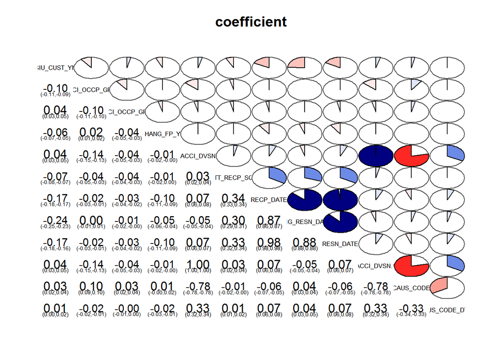

```r
## change features of factor type to numeric type for inclusion on correlogram
corrgram.data$SIU_CUST_YN <- as.numeric(corrgram.data$SIU_CUST_YN)
corrgram.data$ACCI_OCCP_GRP1 <- as.numeric(corrgram.data$ACCI_OCCP_GRP1)
corrgram.data$ACCI_OCCP_GRP2 <- as.numeric(corrgram.data$ACCI_OCCP_GRP2)
corrgram.data$CHANG_FP_YN <- as.numeric(corrgram.data$CHANG_FP_YN)
corrgram.data$ACCI_DVSN <- as.numeric (corrgram.data$ACCI_DVSN)
corrgram.data$CAUS_CODE <- as.numeric (corrgram.data$CAUS_CODE)
corrgram.data$CAUS_CODE_DTAL <- as.numeric (corrgram.data$CAUS_CODE_DTAL)
corrgram.data$RESL_CD1 <- as.numeric (corrgram.data$RESL_CD1)
corrgram.data$RESL_NM1 <- as.numeric (corrgram.data$RESL_NM1)
corrgram.data$ACCI_HOSP_ADDR <- as.numeric (corrgram.data$ACCI_HOSP_ADDR)
corrgram.data$PMMI_DLNG_YN <- as.numeric (corrgram.data$PMMI_DLNG_YN)
corrgram.data$HEED_HOSP_YN <- as.numeric (corrgram.data$HEED_HOSP_YN)
corrgram.data$CAUS_CODE_FIRST <- as.numeric (factor(corrgram.data$CAUS_CODE_FIRST))
corrgram.data$RESL_CD1_FIRST <- as.numeric (factor(corrgram.data$RESL_CD1_FIRST))

## generate correlogram : 피어슨 상관계수 계산
corrgram.vars <- c("SIU_CUST_YN", "ACCI_OCCP_GRP1", "ACCI_OCCP_GRP2", "CHANG_FP_YN", "ACCI_DVSN", "CNTT_RECP_SQNO", "RECP_DATE", "ORIG_RESN_DATE", "RESN_DATE","CRNT_PROG_DVSN","ACCI_DVSN","CAUS_CODE","CAUS_CODE_DTAL")
corrgram(corrgram.data[,corrgram.vars], order=FALSE, lower.panel=panel.conf, upper.panel=panel.pie, text.panel=panel.txt, main="coefficient")
```

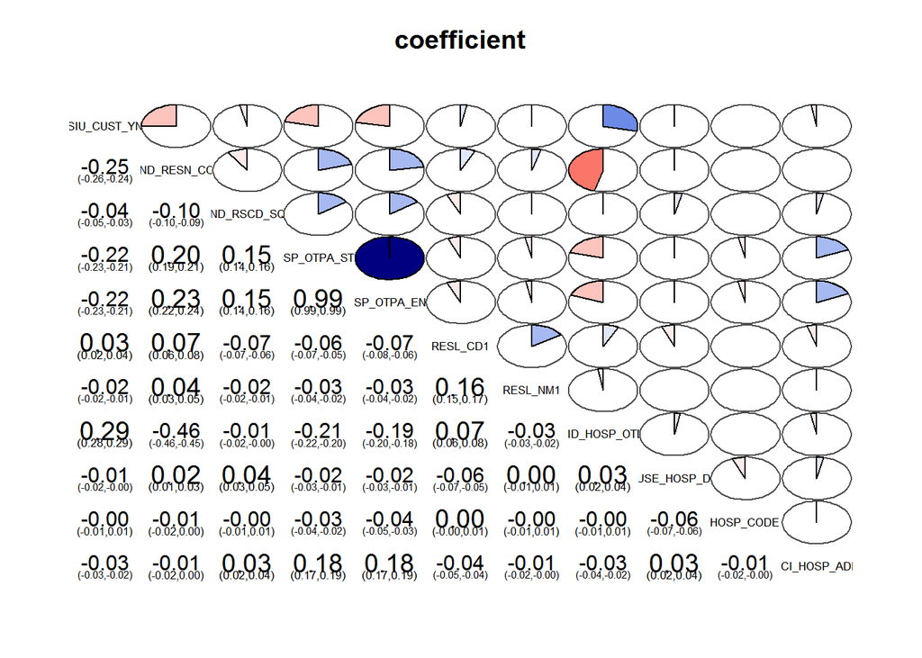

```r
corrgram.vars <- c("SIU_CUST_YN", "DSAS_NAME", "DMND_RESN_CODE", "DMND_RSCD_SQNO", "HOSP_OTPA_STDT", "HOSP_OTPA_ENDT", "RESL_CD1", "RESL_NM1","VLID_HOSP_OTDA","HOUSE_HOSP_DIST","HOSP_CODE","ACCI_HOSP_ADDR")
corrgram(corrgram.data[,corrgram.vars], order=FALSE, lower.panel=panel.conf, upper.panel=panel.pie, text.panel=panel.txt, main="coefficient")
```

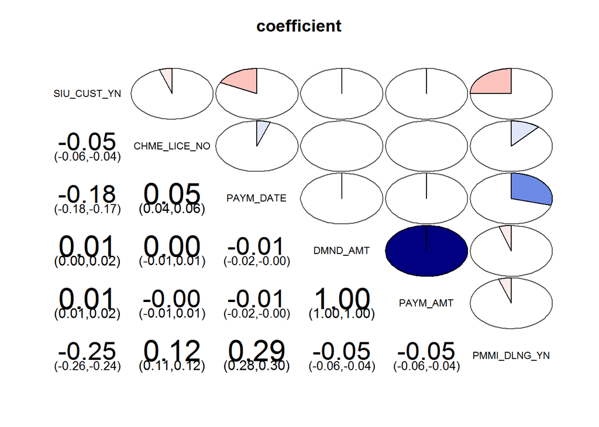

```r
corrgram.vars <- c("SIU_CUST_YN", "HOSP_SPEC_DVSN", "CHME_LICE_NO", "PAYM_DATE", "DMND_AMT", "PAYM_AMT", "PMMI_DLNG_YN")
#, "SELF_CHAM", "NON_PAY", "TAMT_SFCA","PATT_CHRG_TOTA","DSCT_AMT") #표준편차 0으로 에러 발생
corrgram(corrgram.data[,corrgram.vars], order=FALSE, lower.panel=panel.conf, upper.panel=panel.pie, text.panel=panel.txt, main="coefficient")
```

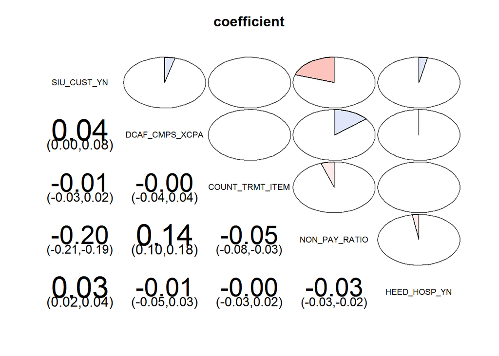

```r
corrgram.vars <- c("SIU_CUST_YN", "DCAF_CMPS_XCPA", "COUNT_TRMT_ITEM", "NON_PAY_RATIO", "HEED_HOSP_YN")
#, "DCAF_CMPS_XCPA", "NON_PAY_RATIO", "HEED_HOSP_YN", "SUB_CUST_ID", "FMLY_RELN_CODE") #표준편차 0으로 에러 발생
corrgram(corrgram.data[,corrgram.vars], order=FALSE, lower.panel=panel.conf, upper.panel=panel.pie, text.panel=panel.txt, main="coefficient")
```

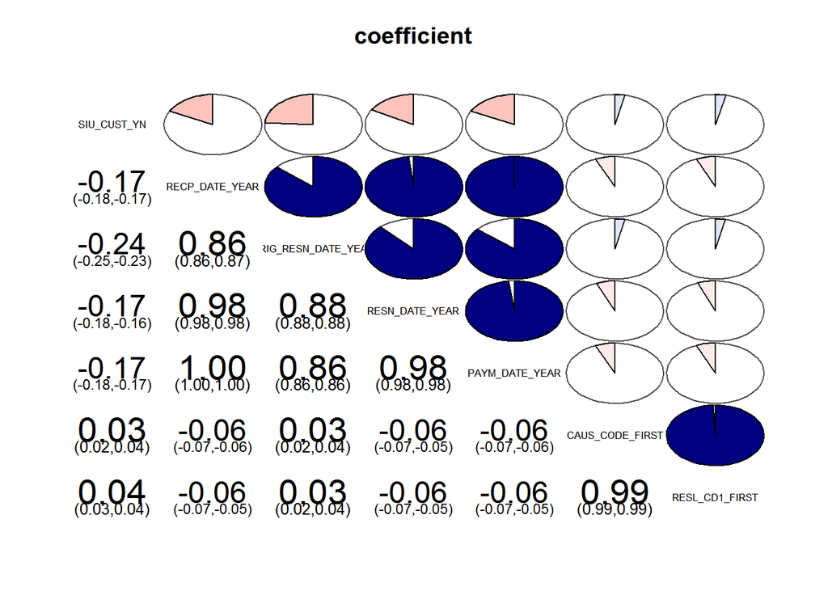

```r
#### 추가분
corrgram.vars <- c("SIU_CUST_YN", "RECP_DATE_YEAR", "ORIG_RESN_DATE_YEAR", "RESN_DATE_YEAR", "PAYM_DATE_YEAR", "CAUS_CODE_FIRST", "RESL_CD1_FIRST")
corrgram(corrgram.data[,corrgram.vars], order=FALSE, lower.panel=panel.conf, upper.panel=panel.pie, text.panel=panel.txt, main="coefficient")
```

```r
#####BGCON_CUST_DATA.df
corrgram.data <- BGCON_CUST_FMLY_DATA.df.down
names(corrgram.data)
```

```
##  [1] "CUST_ID"               "DIVIDED_SET"
##  [3] "SIU_CUST_YN"           "SEX"
##  [5] "AGE"                   "RESI_COST"
##  [7] "RESI_TYPE_CODE"        "FP_CAREER"
##  [9] "CUST_RGST"             "CTPR"
## [11] "OCCP_GRP_1"            "OCCP_GRP_2"
## [13] "TOTALPREM"             "MINCRDT"
## [15] "MAXCRDT"               "WEDD_YN"
## [17] "MATE_OCCP_GRP_1"       "MATE_OCCP_GRP_2"
## [19] "CHLD_CNT"              "LTBN_CHLD_AGE"
## [21] "MAX_PAYM_YM"           "MAX_PRM"
## [23] "CUST_INCM"             "RCBASE_HSHD_INCM"
## [25] "JPBASE_HSHD_INCM"      "SUB_CUST_ID"
## [27] "FMLY_RELN_CODE"        "CUST_RGST_YEAR"
## [29] "MAX_PAYM_YM_YEAR"      "VLID_HOSP_OTDA_TOTAL"
## [31] "HOUSE_HOSP_DIST_TOTAL" "DMND_AMT_TOTAL"
## [33] "PAYM_AMT_TOTAL"        "SELF_CHAM_TOTAL"
## [35] "NON_PAY_TOTAL"         "TAMT_SFCA_TOTAL"
## [37] "PATT_CHRG_TOTA_TOTAL"  "DSCT_AMT_TOTAL"
## [39] "COUNT_TRMT_ITEM_TOTAL" "REAL_PAYM_TERM_TOTAL"
## [41] "MAIN_INSR_AMT_TOTAL"   "SUM_ORIG_PREM_TOTAL"
## [43] "MNTH_INCM_AMT_TOTAL"   "DISTANCE_TOTAL"
## [45] "Class"
```

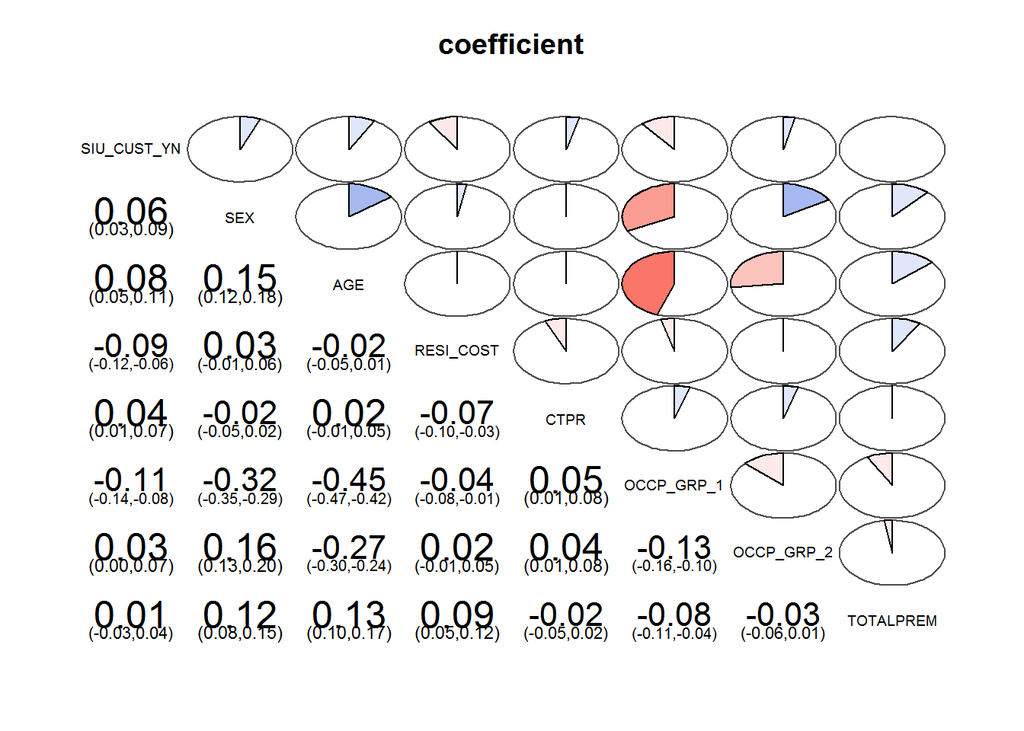

```r
## change features of factor type to numeric type for inclusion on correlogram
corrgram.data$SIU_CUST_YN <- as.numeric(corrgram.data$SIU_CUST_YN)
corrgram.data$FP_CAREER <- as.numeric(corrgram.data$FP_CAREER)
corrgram.data$CTPR <- as.numeric(corrgram.data$CTPR)
corrgram.data$OCCP_GRP_1 <- as.numeric (corrgram.data$OCCP_GRP_1)
corrgram.data$OCCP_GRP_2 <- as.numeric (corrgram.data$OCCP_GRP_2)
corrgram.data$WEDD_YN <- as.numeric (corrgram.data$WEDD_YN)
corrgram.data$MATE_OCCP_GRP_1 <- as.numeric (corrgram.data$MATE_OCCP_GRP_1)
corrgram.data$MATE_OCCP_GRP_2 <- as.numeric (corrgram.data$MATE_OCCP_GRP_2)


## generate correlogram : 피어슨 상관계수 계산
corrgram.vars <- c("SIU_CUST_YN",  "SEX",  "AGE",  "RESI_COST", "CTPR", "OCCP_GRP_1", "OCCP_GRP_2", "TOTALPREM")
corrgram(corrgram.data[,corrgram.vars], order=FALSE, lower.panel=panel.conf, upper.panel=panel.pie, text.panel=panel.txt, main="coefficient")
```

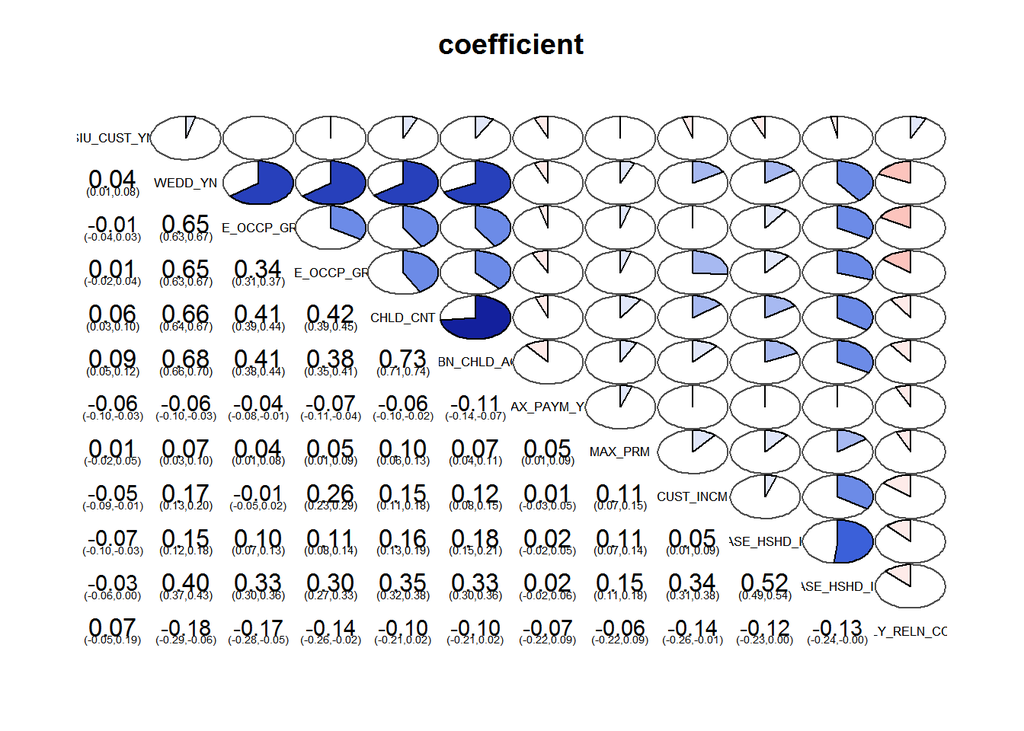

```r
corrgram.vars <- c("SIU_CUST_YN", "MINCRDT", "MAXCRDT", "WEDD_YN", "MATE_OCCP_GRP_1", "MATE_OCCP_GRP_2", "CHLD_CNT", "LTBN_CHLD_AGE", "MAX_PAYM_YM", "MAX_PRM", "CUST_INCM", "RCBASE_HSHD_INCM", "JPBASE_HSHD_INCM", "FMLY_RELN_CODE")
corrgram(corrgram.data[,corrgram.vars], order=FALSE, lower.panel=panel.conf, upper.panel=panel.pie, text.panel=panel.txt, main="coefficient")
```

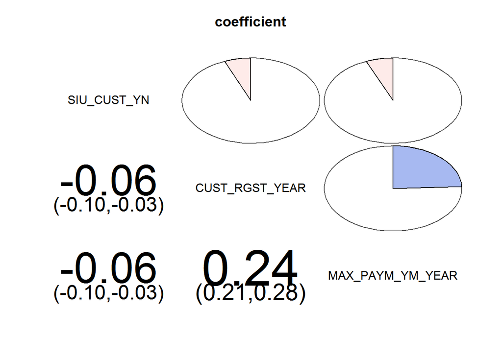

```r
#### 추가분
corrgram.vars <- c("SIU_CUST_YN", "CUST_RGST_YEAR", "MAX_PAYM_YM_YEAR")
corrgram(corrgram.data[,corrgram.vars], order=FALSE, lower.panel=panel.conf, upper.panel=panel.pie, text.panel=panel.txt, main="coefficient")
```

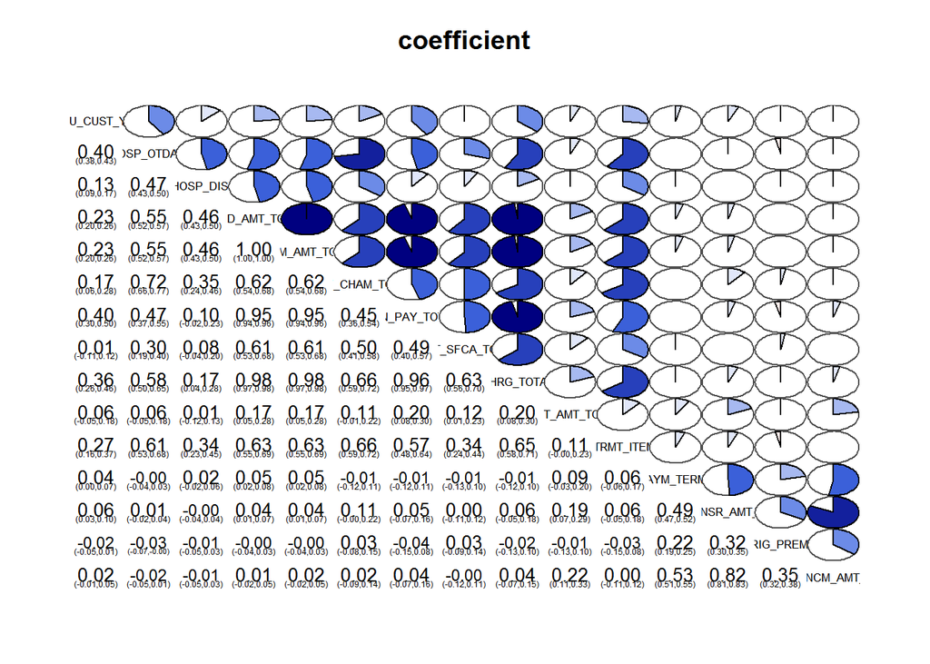

```r
#### 요건 변수 추가분
corrgram.vars <- c("SIU_CUST_YN", "VLID_HOSP_OTDA_TOTAL", "HOUSE_HOSP_DIST_TOTAL", "DMND_AMT_TOTAL", "PAYM_AMT_TOTAL", "SELF_CHAM_TOTAL", "NON_PAY_TOTAL", "TAMT_SFCA_TOTAL", "PATT_CHRG_TOTA_TOTAL", "DSCT_AMT_TOTAL", "COUNT_TRMT_ITEM_TOTAL", "REAL_PAYM_TERM_TOTAL", "MAIN_INSR_AMT_TOTAL", "SUM_ORIG_PREM_TOTAL", "MNTH_INCM_AMT_TOTAL")
corrgram(corrgram.data[,corrgram.vars], order=FALSE, lower.panel=panel.conf, upper.panel=panel.pie, text.panel=panel.txt, main="coefficient")
```

```r
#####BGCON_CUST_DATA.df
corrgram.data <- BGCON_CNTT_FPINFO_DATA.df.down
names(corrgram.data)
```

```
##  [1] "CLLT_FP_PRNO"   "POLY_NO"        "CUST_ID"        "CUST_ROLE"
##  [5] "IRKD_CODE_DTAL" "IRKD_CODE_ITEM" "GOOD_CLSF_CDNM" "CNTT_YM"
##  [9] "REAL_PAYM_TERM" "SALE_CHNL_CODE" "CNTT_STAT_CODE" "EXPR_YM"
## [13] "EXTN_YM"        "LAPS_YM"        "PAYM_CYCL_CODE" "MAIN_INSR_AMT"
## [17] "SUM_ORIG_PREM"  "RECP_PUBL"      "CNTT_RECP"      "MNTH_INCM_AMT"
## [21] "DISTANCE"       "SIU_CUST_YN"    "INCB_DVSN"      "ETRS_YM"
## [25] "FIRE_YM"        "BEFO_JOB"       "EDGB"           "BRCH_CODE"
## [29] "CNTT_YM_YEAR"   "EXPR_YM_YEAR"   "EXTN_YM_YEAR"   "LAPS_YM_YEAR"
## [33] "ETRS_YM_YEAR"   "FIRE_YM_YEAR"   "Class"
```

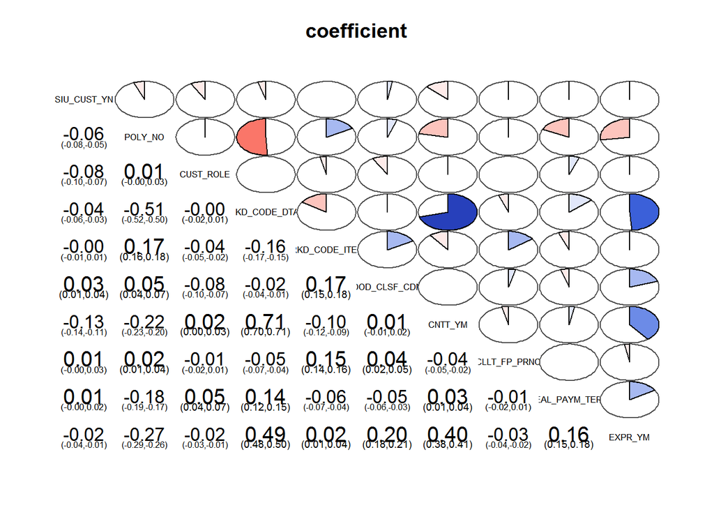

```r
## change features of factor type to numeric type for inclusion on correlogram
corrgram.data$SIU_CUST_YN <- as.numeric(corrgram.data$SIU_CUST_YN)
corrgram.data$GOOD_CLSF_CDNM <- as.numeric(corrgram.data$GOOD_CLSF_CDNM)
corrgram.data$CLLT_FP_PRNO <- as.numeric(corrgram.data$CLLT_FP_PRNO)
corrgram.data$INCB_DVSN <- as.numeric(corrgram.data$INCB_DVSN)
corrgram.data$ETRS_YM <- as.numeric(corrgram.data$ETRS_YM)
corrgram.data$FIRE_YM <- as.numeric(corrgram.data$FIRE_YM)
corrgram.data$BEFO_JOB <- as.numeric(corrgram.data$BEFO_JOB)
corrgram.data$EDGB <- as.numeric(corrgram.data$EDGB)
corrgram.data$BRCH_CODE <- as.numeric(corrgram.data$BRCH_CODE)

## generate correlogram : 피어슨 상관계수 계산
corrgram.vars <- c("SIU_CUST_YN", "POLY_NO", "CUST_ROLE", "IRKD_CODE_DTAL", "IRKD_CODE_ITEM", "GOOD_CLSF_CDNM", "CNTT_YM", "CLLT_FP_PRNO", "REAL_PAYM_TERM", "SALE_CHNL_CODE", "CNTT_STAT_CODE", "EXPR_YM")
corrgram(corrgram.data[,corrgram.vars], order=FALSE, lower.panel=panel.conf, upper.panel=panel.pie, text.panel=panel.txt, main="coefficient")
```

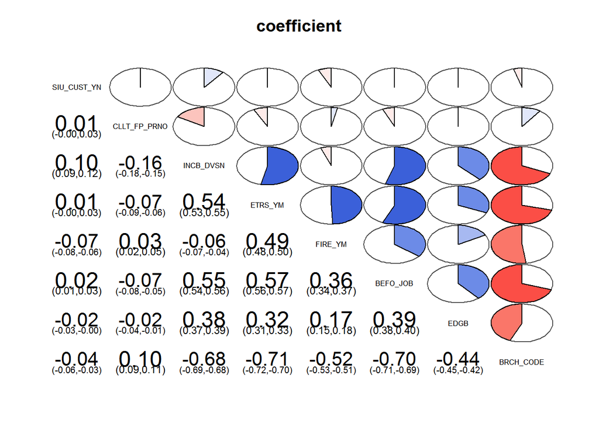

```r
## generate correlogram : 피어슨 상관계수 계산
corrgram.vars <- c("SIU_CUST_YN", "CLLT_FP_PRNO", "INCB_DVSN", "ETRS_YM", "FIRE_YM", "BEFO_JOB", "EDGB", "BRCH_CODE")
corrgram(corrgram.data[,corrgram.vars], order=FALSE, lower.panel=panel.conf, upper.panel=panel.pie, text.panel=panel.txt, main="coefficient")
```

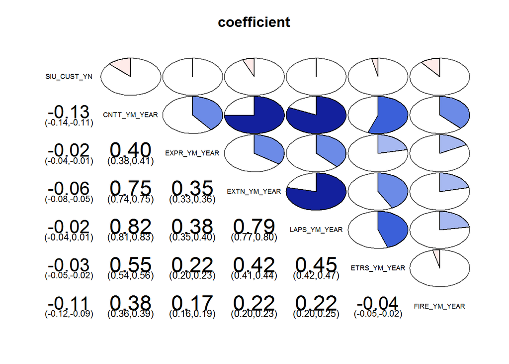

```r
#### 추가분
corrgram.vars <- c("SIU_CUST_YN", "CNTT_YM_YEAR", "EXPR_YM_YEAR", "EXTN_YM_YEAR", "LAPS_YM_YEAR", "ETRS_YM_YEAR", "FIRE_YM_YEAR")
corrgram(corrgram.data[,corrgram.vars], order=FALSE, lower.panel=panel.conf, upper.panel=panel.pie, text.panel=panel.txt, main="coefficient")
```

- 데이터가 많기 때문에 p-value 계산으로 볼때 0.06 이상은 귀무가설 기각
- 상관분석에서 유의미하게 본 데이터들이 correlation이 높게 나옴

## Feature Importance 확인을 위한 모델 테스트

### CART(Classification And Regression Tree)

- ctree(Conditional Inference Tree)
- BGCON_CNTT_FPINFO_DATA.df.down
- train 16386, test 4096
- Accuracy 0.6787109 (2780/4096)
- BGCON_CUST_FMLY_DATA.df.down
- train 2962, test 740
- Accuracy 0.5851351 (433/740)

```r
#### column 별 Missing Data 갯수 출력
#### missing data 출력해주는 함수
print_missing_count <- function(df){
  for (name in colnames(df)){
    cat(name, "(", class(df[, name]), ")" , "====",  sum(is.na(df[, name])))
    cat("\n")
  }
}
print_missing_count(BGCON_CLAIM_DATA.df.down)
```

```
## CUST_ID ( integer ) ==== 0
## POLY_NO ( integer ) ==== 0
## ACCI_OCCP_GRP1 ( factor ) ==== 0
## ACCI_OCCP_GRP2 ( factor ) ==== 0
## CHANG_FP_YN ( factor ) ==== 0
## CNTT_RECP_SQNO ( numeric ) ==== 0
## RECP_DATE ( integer ) ==== 0
## ORIG_RESN_DATE ( integer ) ==== 0
## RESN_DATE ( integer ) ==== 0
## CRNT_PROG_DVSN ( factor ) ==== 0
## ACCI_DVSN ( factor ) ==== 0
## CAUS_CODE ( factor ) ==== 0
## CAUS_CODE_DTAL ( factor ) ==== 0
## DSAS_NAME ( factor ) ==== 0
## DMND_RESN_CODE ( integer ) ==== 0
## DMND_RSCD_SQNO ( integer ) ==== 0
## HOSP_OTPA_STDT ( integer ) ==== 11224
## HOSP_OTPA_ENDT ( integer ) ==== 11224
## RESL_CD1 ( factor ) ==== 0
## RESL_NM1 ( factor ) ==== 0
## VLID_HOSP_OTDA ( integer ) ==== 0
## HOUSE_HOSP_DIST ( numeric ) ==== 8491
## HOSP_CODE ( integer ) ==== 4
## ACCI_HOSP_ADDR ( factor ) ==== 0
## HOSP_SPEC_DVSN ( factor ) ==== 4
## CHME_LICE_NO ( integer ) ==== 0
## PAYM_DATE ( integer ) ==== 7
## DMND_AMT ( integer ) ==== 0
## PAYM_AMT ( integer ) ==== 0
## PMMI_DLNG_YN ( factor ) ==== 0
## SELF_CHAM ( integer ) ==== 43318
## NON_PAY ( integer ) ==== 43318
## TAMT_SFCA ( integer ) ==== 43318
## PATT_CHRG_TOTA ( integer ) ==== 43318
## DSCT_AMT ( integer ) ==== 43318
## COUNT_TRMT_ITEM ( integer ) ==== 43318
## DCAF_CMPS_XCPA ( integer ) ==== 46635
## NON_PAY_RATIO ( numeric ) ==== 0
## HEED_HOSP_YN ( factor ) ==== 0
## SIU_CUST_YN ( factor ) ==== 0
## RECP_DATE_YEAR ( numeric ) ==== 0
## ORIG_RESN_DATE_YEAR ( numeric ) ==== 0
## RESN_DATE_YEAR ( numeric ) ==== 0
## PAYM_DATE_YEAR ( numeric ) ==== 7
## CAUS_CODE_FIRST ( character ) ==== 0
## RESL_CD1_FIRST ( character ) ==== 0
## Class ( factor ) ==== 0
```

```r
print_missing_count(BGCON_CUST_FMLY_DATA.df.down)
```

```
## CUST_ID ( integer ) ==== 0
## DIVIDED_SET ( integer ) ==== 0
## SIU_CUST_YN ( factor ) ==== 0
## SEX ( integer ) ==== 0
## AGE ( integer ) ==== 0
## RESI_COST ( integer ) ==== 0
## RESI_TYPE_CODE ( factor ) ==== 165
## FP_CAREER ( factor ) ==== 0
## CUST_RGST ( integer ) ==== 70
## CTPR ( factor ) ==== 0
## OCCP_GRP_1 ( factor ) ==== 0
## OCCP_GRP_2 ( factor ) ==== 0
## TOTALPREM ( integer ) ==== 791
## MINCRDT ( factor ) ==== 1648
## MAXCRDT ( factor ) ==== 1648
## WEDD_YN ( factor ) ==== 0
## MATE_OCCP_GRP_1 ( factor ) ==== 0
## MATE_OCCP_GRP_2 ( factor ) ==== 0
## CHLD_CNT ( integer ) ==== 70
## LTBN_CHLD_AGE ( integer ) ==== 70
## MAX_PAYM_YM ( integer ) ==== 924
## MAX_PRM ( integer ) ==== 924
## CUST_INCM ( integer ) ==== 744
## RCBASE_HSHD_INCM ( integer ) ==== 0
## JPBASE_HSHD_INCM ( integer ) ==== 108
## SUB_CUST_ID ( integer ) ==== 3432
## FMLY_RELN_CODE ( integer ) ==== 3432
## CUST_RGST_YEAR ( numeric ) ==== 100
## MAX_PAYM_YM_YEAR ( numeric ) ==== 924
## VLID_HOSP_OTDA_TOTAL ( integer ) ==== 0
## HOUSE_HOSP_DIST_TOTAL ( numeric ) ==== 1699
## DMND_AMT_TOTAL ( integer ) ==== 0
## PAYM_AMT_TOTAL ( integer ) ==== 0
## SELF_CHAM_TOTAL ( integer ) ==== 3408
## NON_PAY_TOTAL ( integer ) ==== 3408
## TAMT_SFCA_TOTAL ( integer ) ==== 3408
## PATT_CHRG_TOTA_TOTAL ( integer ) ==== 3408
## DSCT_AMT_TOTAL ( integer ) ==== 3408
## COUNT_TRMT_ITEM_TOTAL ( integer ) ==== 3408
## REAL_PAYM_TERM_TOTAL ( integer ) ==== 0
## MAIN_INSR_AMT_TOTAL ( integer ) ==== 27
## SUM_ORIG_PREM_TOTAL ( integer ) ==== 17
## MNTH_INCM_AMT_TOTAL ( integer ) ==== 17
## DISTANCE_TOTAL ( integer ) ==== 539
## Class ( factor ) ==== 0
```

```r
print_missing_count(BGCON_CNTT_FPINFO_DATA.df.down)
```

```
## CLLT_FP_PRNO ( integer ) ==== 18
## POLY_NO ( integer ) ==== 0
## CUST_ID ( integer ) ==== 0
## CUST_ROLE ( integer ) ==== 0
## IRKD_CODE_DTAL ( integer ) ==== 0
## IRKD_CODE_ITEM ( integer ) ==== 0
## GOOD_CLSF_CDNM ( factor ) ==== 0
## CNTT_YM ( integer ) ==== 0
## REAL_PAYM_TERM ( integer ) ==== 0
## SALE_CHNL_CODE ( factor ) ==== 0
## CNTT_STAT_CODE ( factor ) ==== 0
## EXPR_YM ( integer ) ==== 18
## EXTN_YM ( integer ) ==== 8783
## LAPS_YM ( integer ) ==== 15877
## PAYM_CYCL_CODE ( factor ) ==== 18
## MAIN_INSR_AMT ( integer ) ==== 18
## SUM_ORIG_PREM ( integer ) ==== 18
## RECP_PUBL ( integer ) ==== 18
## CNTT_RECP ( integer ) ==== 18
## MNTH_INCM_AMT ( integer ) ==== 18
## DISTANCE ( integer ) ==== 1635
## SIU_CUST_YN ( factor ) ==== 0
## INCB_DVSN ( factor ) ==== 18
## ETRS_YM ( factor ) ==== 18
## FIRE_YM ( factor ) ==== 18
## BEFO_JOB ( factor ) ==== 18
## EDGB ( factor ) ==== 18
## BRCH_CODE ( integer ) ==== 19
## CNTT_YM_YEAR ( numeric ) ==== 0
## EXPR_YM_YEAR ( numeric ) ==== 18
## EXTN_YM_YEAR ( numeric ) ==== 8783
## LAPS_YM_YEAR ( numeric ) ==== 15877
## ETRS_YM_YEAR ( numeric ) ==== 1496
## FIRE_YM_YEAR ( numeric ) ==== 1479
## Class ( factor ) ==== 0
```

### Model Test

#### Logistic Regression

- Step wise를 이용하여 종속변수집단을 선택하였더니 정확도가 유의미하게 변하였음

```
#install.packages("rattle")
#install.packages("rpart.plot")
#install.packages("caret")
suppressPackageStartupMessages({
  library(rpart)
  library(party)
  library(caret)
  library(pROC)
})
#memory.limit(100000)

#입력할 데이터
df.train <- BGCON_CUST_FMLY_DATA.df.down
df.train$Class <- NULL

set.seed(23)
training.rows <- createDataPartition(df.train$SIU_CUST_YN,  p = 0.8, list = FALSE)
train.batch <- df.train[training.rows, ]
test.batch <- df.train[-training.rows, ]

set.seed(23)
step(glm(SIU_CUST_YN ~ + DIVIDED_SET + SEX + AGE + RESI_COST + FP_CAREER + CTPR + OCCP_GRP_1 + OCCP_GRP_2 + RCBASE_HSHD_INCM + VLID_HOSP_OTDA_TOTAL + DMND_AMT_TOTAL + PAYM_AMT_TOTAL + REAL_PAYM_TERM_TOTAL, data = train.batch, family=binomial("logit")))

glm.tune.1 <- train(SIU_CUST_YN ~ RESI_COST + CTPR + OCCP_GRP_1 + VLID_HOSP_OTDA_TOTAL + PAYM_AMT_TOTAL
                    ,data = train.batch
                    ,method = "glm"
                    ,metric = "ROC"  ## ROC 구체적으로는 AUC 가 최대가 되도록 최적화 하겠다는 의미임
                    ,trControl = cv.ctrl)
glm.tune.1
summary(glm.tune.1)

#### Model Evaluation
glm.pred.1 <- predict(glm.tune.1, test.batch)
confusionMatrix(glm.pred.1, test.batch$SIU_CUST_YN)
```

```
Call:
NULL

Deviance Residuals:
    Min       1Q   Median       3Q      Max
-6.1285  -0.8155  -0.0002   0.8389   2.3852

Coefficients:
                       Estimate Std. Error z value Pr(>|z|)
(Intercept)          -2.834e+00  5.005e-01  -5.661 1.50e-08 ***
RESI_COST            -1.198e-05  3.577e-06  -3.350 0.000810 ***
CTPR강원              1.908e+00  7.110e-01   2.684 0.007268 **
CTPR경기              1.750e+00  6.704e-01   2.611 0.009041 **
CTPR경남              1.140e+00  6.895e-01   1.654 0.098147 .
CTPR경북              1.684e+00  7.076e-01   2.380 0.017328 *
CTPR광주              2.588e+00  6.883e-01   3.760 0.000170 ***
CTPR대구              1.188e+00  7.043e-01   1.687 0.091682 .
CTPR대전              2.992e+00  7.244e-01   4.131 3.62e-05 ***
CTPR부산              2.196e+00  6.809e-01   3.225 0.001260 **
CTPR서울              2.134e+00  6.745e-01   3.164 0.001555 **
CTPR세종             -2.858e+00  5.148e+00  -0.555 0.578715
CTPR울산              1.179e+00  7.338e-01   1.606 0.108195
CTPR인천              2.432e+00  6.797e-01   3.578 0.000347 ***
CTPR전남              1.655e+00  6.870e-01   2.408 0.016023 *
CTPR전북              1.848e+00  6.920e-01   2.670 0.007588 **
CTPR제주             -1.291e+01  3.351e+02  -0.039 0.969277
CTPR충남              1.795e+00  7.173e-01   2.502 0.012342 *
CTPR충북              4.119e-01  7.802e-01   0.528 0.597543
OCCP_GRP_11.주부      1.823e-01  5.992e-01   0.304 0.760931
OCCP_GRP_12.자영업    4.184e-01  6.043e-01   0.692 0.488759
OCCP_GRP_13.사무직    1.854e-01  6.009e-01   0.309 0.757628
OCCP_GRP_14.전문직   -1.832e-01  6.185e-01  -0.296 0.767107
OCCP_GRP_15.서비스    1.114e-01  6.061e-01   0.184 0.854167
OCCP_GRP_16.제조업   -7.257e-01  6.300e-01  -1.152 0.249371
OCCP_GRP_17.1차산업  -9.806e-01  7.656e-01  -1.281 0.200223
OCCP_GRP_18.기타     -2.847e-01  6.020e-01  -0.473 0.636253
VLID_HOSP_OTDA_TOTAL  1.371e-02  7.428e-04  18.459  < 2e-16 ***
PAYM_AMT_TOTAL        1.004e-08  4.681e-09   2.146 0.031894 *
---
Signif. codes:  0 ‘***’ 0.001 ‘**’ 0.01 ‘*’ 0.05 ‘.’ 0.1 ‘ ’ 1

(Dispersion parameter for binomial family taken to be 1)

    Null deviance: 4106.2  on 2961  degrees of freedom
Residual deviance: 2937.8  on 2933  degrees of freedom
AIC: 2995.8

Number of Fisher Scoring iterations: 14
```

```
Confusion Matrix and Statistics

          Reference
Prediction   N   Y
         N 330 109
         Y  40 261

               Accuracy : 0.7986
                 95% CI : (0.7679, 0.827)
    No Information Rate : 0.5
    P-Value [Acc > NIR] : < 2.2e-16

                  Kappa : 0.5973
 Mcnemar's Test P-Value : 2.536e-08

            Sensitivity : 0.8919
            Specificity : 0.7054
         Pos Pred Value : 0.7517
         Neg Pred Value : 0.8671
             Prevalence : 0.5000
         Detection Rate : 0.4459
   Detection Prevalence : 0.5932
      Balanced Accuracy : 0.7986

       'Positive' Class : N
```

#### SVM

- Logistic Regression 보다 성능이 떨어지는 것으로 보아 데이터의 특성이 특정 변수 필드에 걸려지는 Simple한 결과가 아닌것으로 보임
  - Tree Based Model이 적합할 것으로 보임

```
#입력할 데이터
df.train <- BGCON_CUST_FMLY_DATA.df.down
df.train$Class <- NULL

set.seed(23)
training.rows <- createDataPartition(df.train$SIU_CUST_YN,  p = 0.8, list = FALSE)
train.batch <- df.train[training.rows, ]
test.batch <- df.train[-training.rows, ]


#### SVM Model Train
set.seed(23)
svm.tune.1 <- train(SIU_CUST_YN ~ RESI_COST + CTPR + OCCP_GRP_1 + VLID_HOSP_OTDA_TOTAL + PAYM_AMT_TOTAL
                    ,data = train.batch
                    ,method = "svmRadial"
                    ,tuneLength = 9
                    ,preProcess = c("center", "scale")
                    ,metric = "ROC"
                    ,trControl = cv.ctrl)
svm.tune.1
summary(svm.tune.1)

#### SVM Model Evaluation
svm.pred.1 <- predict(svm.tune.1, test.batch)
confusionMatrix(svm.pred.1, test.batch$SIU_CUST_YN)
```

```
Confusion Matrix and Statistics

          Reference
Prediction   N   Y
         N 314 116
         Y  56 254

               Accuracy : 0.7676
                 95% CI : (0.7354, 0.7976)
    No Information Rate : 0.5
    P-Value [Acc > NIR] : < 2.2e-16

                  Kappa : 0.5351
 Mcnemar's Test P-Value : 6.837e-06

            Sensitivity : 0.8486
            Specificity : 0.6865
         Pos Pred Value : 0.7302
         Neg Pred Value : 0.8194
             Prevalence : 0.5000
         Detection Rate : 0.4243
   Detection Prevalence : 0.5811
      Balanced Accuracy : 0.7676

       'Positive' Class : N
```

#### CART

- tree 기반 테스트

[output not shown]

#### random forest

[output not shown]

#### random forest based Feature Importance Plot

[output not shown]

#### Positive Rule

BGCON_CLAIM_DATA

#### Negative Rule

BGCON_CLAIM_DATA * ACCI_OCCP_GRP2 * 고소득 전문직 * 법무직 종사자 * RESL_CD1 * F 병명 코드 * Z 병명 코드 (기타 쪽으로 분류되는 질환) * CRNT_PROG_DVSN * 21? * 22? * DMND_RESN_CODE * 9? * COUNT_TRMT_ITEM * 0 * 4 * VLID_HOSP_OTDA * 0 이상?

CUST * CHLD_CNT * 5? * MATE_OCCP_GRP_2 * 대학교수/강사 * 고소득 전문직 * MAXCRDT * 28? * OCCP_GRP_2 * 고소득 전문직 * 법무직 종사자 * CTPR * 제주 * 법무직 종사자 * BEFO_JOB * 경찰 * 국영기업체 * 농수축산업